# Explore.1 In class starter

Logan Hardy

01/06/2022

# Update your name and the date at the top of this document.

# Introduction to RStudio

Copy and paste the following code lines into the console one at a time.

random_number <- 3 random_number + random_number plot(1:5)

Look at the four quadrants in RStudio.

Q: How do you change the size of the panes? A: Drag edges to desired size

Q: What is the purpose of each pane? A: R script file, command console, environment/history/tutorial, outputs

# R Markdown vs. Script

Copy and paste the code lines from above into the code chunk below and run them.

This is an R Markdown File (RMD or .rmd). Open a script (.r) and see the difference.

```r
random_number <- 3
random_number + random_number
```

```
## [1] 6
```

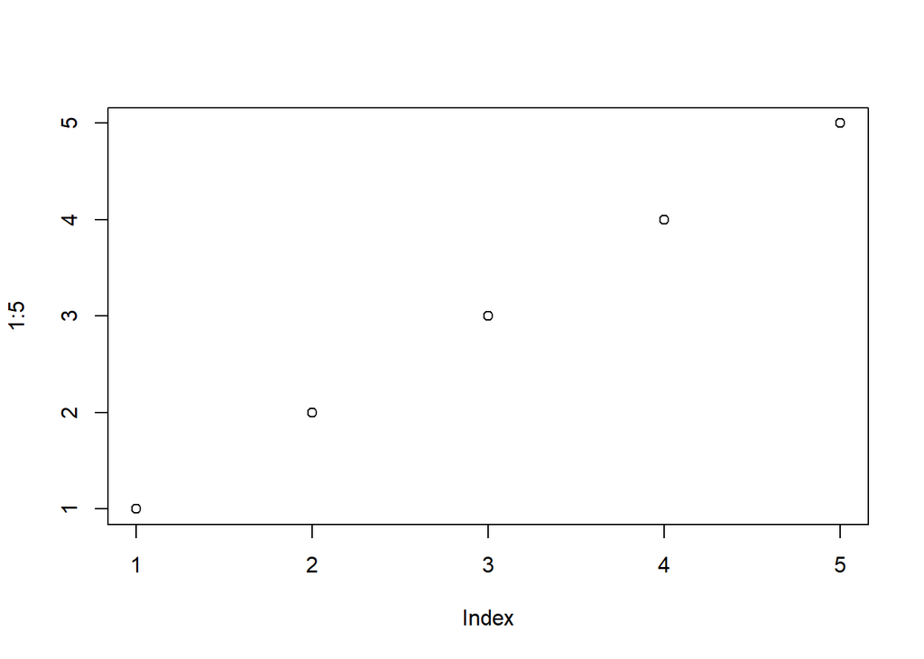

```r
plot(1:5)
```

Q: What are 3 differences between Markdown Files and scripts? A:

# Objects, Vectors, and Lists

You can create both numerical objects and text objects. Create one of each below.

```r
words <- "garlic bread"
number <- 24
```

Saved text is usually referred to as a “string” in R. Can you perform mathematical operations on strings? Try this in the console.

Create two vectors, one numerical and one text. Print them out.

```r
numbers <- c(2:24)
#numbers <- c(3,1,6)
numbers
```

```
##  [1]  2  3  4  5  6  7  8  9 10 11 12 13 14 15 16 17 18 19 20 21 22 23 24
```

```r
(strings <- c("hat", "lemon", "3"))
```

```
## [1] "hat"   "lemon" "3"
```

Create a blank vector

```r
blank <- c()
nas <- c(NA)
```

Create a vector and print it out at the same time.

```r
(numbers2 <- c(1:10))
```

```
##  [1]  1  2  3  4  5  6  7  8  9 10
```

Print out the second value in your string vector.

```r
strings[2]
```

```
## [1] "lemon"
```

Combine two vectors together.

```r
strings3 <- c("hi", "family")
(strings4 <- c(strings, strings3))
```

```
## [1] "hat"    "lemon"  "3"      "hi"     "family"
```

```r
boolean1 <- c(TRUE, FALSE, TRUE)
TRUE + TRUE
```

```
## [1] 2
```

Make a list.

```r
list1 <- list(TRUE, 2, "Sandwich")
```

Make a list within a list. Click on it in the global environment.

```r
list2 <- list(list1, "nice", "class")
```

Access a value in the nested list with its index

```r
list1[3]
```

```
## [[1]]
## [1] "Sandwich"
```

```r
list2[[1]][3]
```

```
## [[1]]
## [1] "Sandwich"
```

Make a named list

```r
list3 <- list("num1" = 23, "num2" = 1, "num3" = 2)
list3
```

```
## $num1
## [1] 23
##
## $num2
## [1] 1
##
## $num3
## [1] 2
```

Access part of a list by its name

```r
list3$num2
```

```
## [1] 1
```

```r
list3[["num2"]]
```

```
## [1] 1
```

```r
list3[[2]]
```

```
## [1] 1
```

Q: What is the difference between a vector and a list? A: vectors are one dimensional and one datatype. Lists can be multidimensional and can store multiple datatypes

# Datasets

Mtcars is a dataset that is always loaded into R. Run the code below to see it.

```r
mtcars
```

```
##                      mpg cyl  disp  hp drat    wt  qsec vs am gear carb
## Mazda RX4           21.0   6 160.0 110 3.90 2.620 16.46  0  1    4    4
## Mazda RX4 Wag       21.0   6 160.0 110 3.90 2.875 17.02  0  1    4    4
## Datsun 710          22.8   4 108.0  93 3.85 2.320 18.61  1  1    4    1
## Hornet 4 Drive      21.4   6 258.0 110 3.08 3.215 19.44  1  0    3    1
## Hornet Sportabout   18.7   8 360.0 175 3.15 3.440 17.02  0  0    3    2
## Valiant             18.1   6 225.0 105 2.76 3.460 20.22  1  0    3    1
## Duster 360          14.3   8 360.0 245 3.21 3.570 15.84  0  0    3    4
## Merc 240D           24.4   4 146.7  62 3.69 3.190 20.00  1  0    4    2
## Merc 230            22.8   4 140.8  95 3.92 3.150 22.90  1  0    4    2
## Merc 280            19.2   6 167.6 123 3.92 3.440 18.30  1  0    4    4
## Merc 280C           17.8   6 167.6 123 3.92 3.440 18.90  1  0    4    4
## Merc 450SE          16.4   8 275.8 180 3.07 4.070 17.40  0  0    3    3
## Merc 450SL          17.3   8 275.8 180 3.07 3.730 17.60  0  0    3    3
## Merc 450SLC         15.2   8 275.8 180 3.07 3.780 18.00  0  0    3    3
## Cadillac Fleetwood  10.4   8 472.0 205 2.93 5.250 17.98  0  0    3    4
## Lincoln Continental 10.4   8 460.0 215 3.00 5.424 17.82  0  0    3    4
## Chrysler Imperial   14.7   8 440.0 230 3.23 5.345 17.42  0  0    3    4
## Fiat 128            32.4   4  78.7  66 4.08 2.200 19.47  1  1    4    1
## Honda Civic         30.4   4  75.7  52 4.93 1.615 18.52  1  1    4    2
## Toyota Corolla      33.9   4  71.1  65 4.22 1.835 19.90  1  1    4    1
## Toyota Corona       21.5   4 120.1  97 3.70 2.465 20.01  1  0    3    1
## Dodge Challenger    15.5   8 318.0 150 2.76 3.520 16.87  0  0    3    2
## AMC Javelin         15.2   8 304.0 150 3.15 3.435 17.30  0  0    3    2
## Camaro Z28          13.3   8 350.0 245 3.73 3.840 15.41  0  0    3    4
## Pontiac Firebird    19.2   8 400.0 175 3.08 3.845 17.05  0  0    3    2
## Fiat X1-9           27.3   4  79.0  66 4.08 1.935 18.90  1  1    4    1
## Porsche 914-2       26.0   4 120.3  91 4.43 2.140 16.70  0  1    5    2
## Lotus Europa        30.4   4  95.1 113 3.77 1.513 16.90  1  1    5    2
## Ford Pantera L      15.8   8 351.0 264 4.22 3.170 14.50  0  1    5    4
## Ferrari Dino        19.7   6 145.0 175 3.62 2.770 15.50  0  1    5    6
## Maserati Bora       15.0   8 301.0 335 3.54 3.570 14.60  0  1    5    8
## Volvo 142E          21.4   4 121.0 109 4.11 2.780 18.60  1  1    4    2
```

Q: What is the structure of a dataset? A: A named list of vectors

Print out the first column of the mtcar dataset by its index.

```r
mtcars[1]
```

```
##                      mpg
## Mazda RX4           21.0
## Mazda RX4 Wag       21.0
## Datsun 710          22.8
## Hornet 4 Drive      21.4
## Hornet Sportabout   18.7
## Valiant             18.1
## Duster 360          14.3
## Merc 240D           24.4
## Merc 230            22.8
## Merc 280            19.2
## Merc 280C           17.8
## Merc 450SE          16.4
## Merc 450SL          17.3
## Merc 450SLC         15.2
## Cadillac Fleetwood  10.4
## Lincoln Continental 10.4
## Chrysler Imperial   14.7
## Fiat 128            32.4
## Honda Civic         30.4
## Toyota Corolla      33.9
## Toyota Corona       21.5
## Dodge Challenger    15.5
## AMC Javelin         15.2
## Camaro Z28          13.3
## Pontiac Firebird    19.2
## Fiat X1-9           27.3
## Porsche 914-2       26.0
## Lotus Europa        30.4
## Ford Pantera L      15.8
## Ferrari Dino        19.7
## Maserati Bora       15.0
## Volvo 142E          21.4
```

Print out the first column of the mtcars dataset by its name.

```r
mtcars$mpg
```

```
##  [1] 21.0 21.0 22.8 21.4 18.7 18.1 14.3 24.4 22.8 19.2 17.8 16.4 17.3 15.2 10.4
## [16] 10.4 14.7 32.4 30.4 33.9 21.5 15.5 15.2 13.3 19.2 27.3 26.0 30.4 15.8 19.7
## [31] 15.0 21.4
```

Save the first value of that vector as an object

```r
first_value <- mtcars$mpg[1]
first_value
```

```
## [1] 21
```

Make a vector called “name” that stores the names of your family members.

```r
name <- c("Logan", "Katelyn", "Thomas", "Jori", "Olivia")
name
```

```
## [1] "Logan"   "Katelyn" "Thomas"  "Jori"    "Olivia"
```

Make a vector called “age” that stores the ages of those family members in the same order.

```r
(age <- c(24, 25, 2, 1, 1))
```

```
## [1] 24 25  2  1  1
```

Make a dataset called “family” that stores these two columns. Print it out.

```r
family <- data.frame(name, age)
family
```

```
##      name age
## 1   Logan  24
## 2 Katelyn  25
## 3  Thomas   2
## 4    Jori   1
## 5  Olivia   1
```

Find the mean of the ages of your family

```r
meanAge <- mean(family$age)
meanAge
```

```
## [1] 10.6
```

Knit this document and look at the output.